# 10 **Mitosis and Meiosis**

> Investigating Mitosis, Meiosis, and the Cellular Basis of Genetic Continuity and Variation

## 10.1 **Learning Objectives**

By the end of this laboratory, students will be able to:

1. Identify and distinguish all major phases of mitosis and meiosis.
2. Explain how chromosome behavior differs between mitosis and meiosis.
3. Calculate the mitotic index from microscopic observations.
4. Analyze how meiosis generates genetic variation through crossing over and independent assortment.
5. Compare chromosome number and DNA content through the cell cycle.
6. Interpret the biological significance of mitosis and meiosis in growth, repair, reproduction, and evolution. [[oercommons.org]](https://oercommons.org/courseware/lesson/97043/overview), [[lagccnsdoer.commons.gc.cuny.edu]](https://lagccnsdoer.commons.gc.cuny.edu/biology/scb-115-biology/lab-6/)

## 10.2 **Background**

Cell division is essential for growth, tissue repair, and reproduction. During mitosis, one diploid parent cell produces two genetically identical diploid daughter cells. During meiosis, a diploid germ cell undergoes two divisions to produce four genetically distinct haploid cells. Meiosis introduces genetic variation through crossing over and independent assortment. [[oercommons.org]](https://oercommons.org/courseware/lesson/97043/overview), [[lamc.edu]](https://www.lamc.edu/sites/lamc.edu/files/2022-11/Bio3%20Lab9%20-%20Mitosis%20and%20Meiosis-8e.pdf)

## 10.3 **Materials**

**Microscopy Station**

- Compound light microscope
- Prepared onion root tip slides
- Prepared whitefish blastula slides
- Lens paper

**Modeling Station**

- Chromosome modeling kit (pipe cleaners, beads, or chromosome models)
- Colored pencils or markers
- Meiosis worksheet

**Data Analysis Station**

- Cell counting grid
- Calculator
- Graph paper or spreadsheet software

## 10.4 **Safety Considerations**

- Carry microscopes using both hands.
- Handle glass slides carefully.
- Keep workstations clean and dry.
- Wash hands before leaving the laboratory.

## 10.5 **Pre-Lab Questions**

1. What is the difference between homologous chromosomes and sister chromatids?
2. Define diploid and haploid.
3. During which phase of the cell cycle is DNA replicated?
4. Why is crossing over important?
5. Why would chromosome number double every generation if meiosis did not occur?

During this activity you will work in *pairs.*

## 10.6 **Part I: Microscopic Examination of Mitosis**

### 10.6.1 **Procedure**

**A. Onion Root Tip Observations**

1. Observe the prepared onion root tip slide under low power.

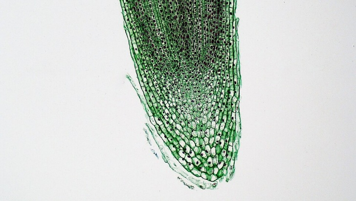

> Micrograph of a longitudinal section of an onion root tip

> **Figure 10.1:** Longitudinal section of an *Allium* (onion) root tip, 40× magnification. https://commons.wikimedia.org/wiki/File:Apical_Meristem_in_Allium_Root_Tip_(23581053848).jpg
2. Locate the apical meristem region. This is within the zones of division.

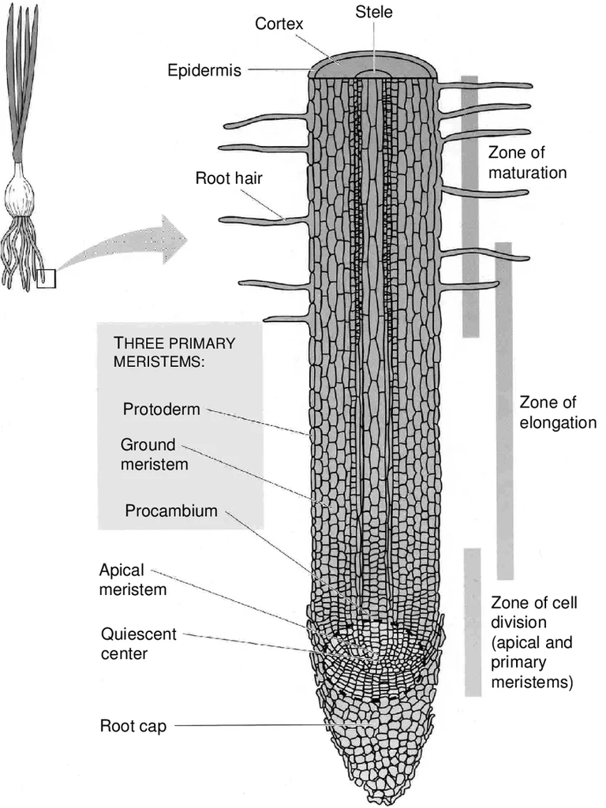

> Diagram of an onion root tip labeling the root cap, apical meristem, and the zones of cell division, elongation, and maturation

> **Figure 10.2:** Main tissues and regions of activity in an onion root tip. https://www.researchgate.net/figure/Main-tissues-and-regions-of-activity-in-an-onion-root-tip-source_fig1_279398426
3. Switch to high power (400×).
4. Identify cells in:
   - Interphase
   - Prophase
   - Metaphase
   - Anaphase
   - Telophase

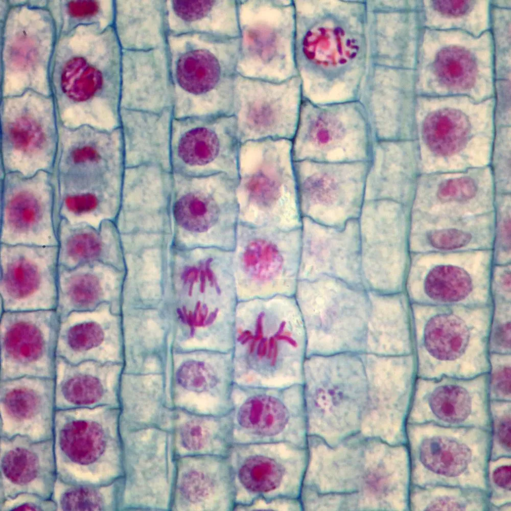

> Micrograph of onion root tip cells in various stages of mitosis

> **Figure 10.3:** Onion root tip cells in various stages of mitosis. https://www.carolina.com/mitosis-meiosis-microscope-slides/onion-mitosis-slide-ls-10-m-quadruple-stain/302408.pr
5. Draw one representative cell from each stage.

   Interphase, Prophase, Metaphase, Anaphase, Telophase
6. Record the distinguishing characteristics of each stage.

**B. Onion Root Tip Analysis**

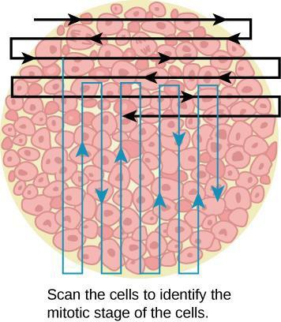

Field of view of cells with horizontal and vertical back-and-forth scanning paths drawn over it

**Figure 10.4:** Scan and count cells by using either a horizontal (black line) or vertical (blue line) back-and-forth scanning technique with your eyes.

1. As you scan the field of view you need to count the number of cells in each stage. Scan different parts of the onion root in three different passes as noted above.
2. Using the prepared slide, record the number of cells in each phase of the cell cycle. Use the method shown in Figure 10.4 to count the cells. Record your count in a data table like that shown in Table 10.1. Share your data with the class to create a group total count.

**Data Table 10.1: Number of Cells Observed**

[output not shown]

### 10.6.2 **Calculating Mitotic Index**

$$\text{Mitotic Index} = \frac{\text{Cells in Mitosis}}{\text{Total Cells Counted}} \times 100$$

Where:

Cells in mitosis = Prophase + Metaphase + Anaphase + Telophase

### 10.6.3 **Questions**

1. Which phase was most common?
2. Based on the percentage of cells observed in each stage, which phase of the cell cycle lasts the longest?
3. What does the most common phase suggest about cell cycle duration?
4. Why are root tips ideal for studying mitosis?

## 10.7 **Part II: Animal Cell Mitosis**

### 10.7.1 **Whitefish Blastula Observations**

1. Locate the whitefish eggs using the scanning lens (40×), then switch to the high power (400×) lens.
2. Scan the prepared whitefish blastula slides as indicated in Figure 10.4.
3. Locate cells undergoing mitosis.
4. Draw one representative cell from each stage.

   Interphase, Prophase, Metaphase, Anaphase, Telophase
5. Compare plant and animal mitotic cells.

**Data Table 10.2: Comparison of Plant and Animal Mitotic Cells**

| **Characteristic** | **Plant Cells** | **Animal Cells** |
| --- | --- | --- |
| Cell shape |  |  |
| Cell wall present? |  |  |
| Cytokinesis mechanism |  |  |
| Centrioles visible? |  |  |

### 10.7.2 **Analysis Questions**

1. How does cytokinesis differ in plants and animals?
2. Why do rapidly growing embryos exhibit high mitotic activity?

## 10.8 **Part III: Modeling Meiosis**

### 10.8.1 **Chromosome Model Activity**

Review the stages of meiosis on the Purple Hubbard Models.

**Starting Condition**

Create a diploid cell (2n = 4) with:

- Pair 1: Red homologous chromosomes
- Pair 2: Blue homologous chromosomes

Each chromosome should consist of two sister chromatids.

**Sketches Required**

Students must draw all of the following stages:

- Prophase I
- Metaphase I
- Anaphase I
- Telophase I
- Prophase II
- Metaphase II
- Anaphase II
- Telophase II
- Final products

Clearly label:

- Homologous chromosomes
- Sister chromatids
- Chiasmata
- Centromeres

### 10.8.2 **Meiosis I**

Model:

1. Prophase I
   - Synapsis
   - Crossing over
2. Metaphase I
   - Homologous pairs line up
3. Anaphase I
   - Homologs separate
4. Telophase I
   - Two haploid cells produced

**Meiosis I Diagrams**

Interphase, Prophase I, Metaphase I, Anaphase I, Telophase I

### 10.8.3 **Meiosis II**

Model:

1. Prophase II
2. Metaphase II
3. Anaphase II
4. Telophase II

**Meiosis II Diagrams**

Prophase II, Metaphase II, Anaphase II, Telophase II

Result: four genetically unique haploid gametes.

## 10.9 **Part IV: Independent Assortment Simulation**

### 10.9.1 **Procedure**

Using the 2n = 4 model:

1. Arrange homologous chromosome pairs randomly at metaphase I.
2. Record resulting gamete combinations.
3. Repeat 10 times.

**Data Table 10.3: Gamete Combinations from Independent Assortment**

| **Trial** | **Gamete Combination** |
| --- | --- |
| 1 |  |
| 2 |  |
| 3 |  |
| 4 |  |
| 5 |  |
| 6 |  |
| 7 |  |
| 8 |  |
| 9 |  |
| 10 |  |

### 10.9.2 **Analysis**

For a species with:

$$n = 23$$

How many chromosome combinations can be produced by independent assortment alone?

Explain how crossing over further increases diversity.

## 10.10 **Part V: Comparing Mitosis and Meiosis**

Complete the table.

**Data Table 10.4: Comparison of Mitosis and Meiosis**

| **Characteristic** | **Mitosis** | **Meiosis** |
| --- | --- | --- |
| Number of divisions |  |  |
| Number of daughter cells |  |  |
| Chromosome number maintained? |  |  |
| Crossing over occurs? |  |  |
| Genetic variation produced? |  |  |
| Cell type produced |  |  |
| Biological purpose |  |  |

## 10.11 **Post-Lab Discussion Questions**

1. Why must DNA replication occur before both mitosis and meiosis?
2. Explain why meiosis I is considered a reduction division.
3. Which meiotic event contributes most to genetic diversity?
4. How could errors during meiosis lead to aneuploidy?
5. Why is mitosis essential for multicellular organisms?
6. Predict the consequences if sister chromatids failed to separate during meiosis II.